# Applied Multivariate: Distance matrices

Load the libraries we will use today

### Similarity and distances

To illustrate the concept of similarity and distance, lets envison a data matrix with 4 sites and 2 species

How can we quantify that distance? One of the simplest methods is the Euclidean distance

### Common distance measures

There are approximately 30 similarity or distances commonly used. [Legendre and Legendre 2012](http://www.ievbras.ru/ecostat/Kiril/R/Biblio/Statistic/Legendre%20P.,%20Legendre%20L.%20Numerical%20ecology.pdf)

The choice of which distance you are going to use depends on the data type and the type of analysis you will do.

#### Euclidean distance

```r
vegdist(hyp_data, method = "euclidean")
```

```
          1         2         3
2  1.000000
3  5.830952  5.385165
4 11.313708 10.630146  5.830952
```

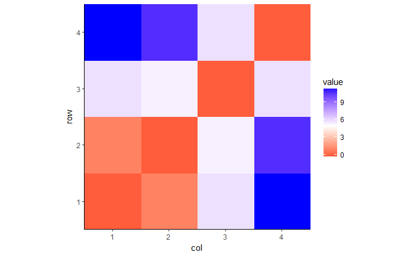

#### City block (Manhattan) distance

- Most ecologically meaningful dissimilarities are Manhattan types
- Less weight to outliers compared to Euclidean
- Retains sensitivity with heterogenous data
- Distances are not proportional

```r
vegdist(hyp_data, method = "manhattan")
```

```
   1  2  3
2  1
3  8  7
4 16 15  8
```

#### Proportional distances

- Manhattan distances expressed as a proportion of the max distance
- 2 communities with nothing in common would be 1

```r
vegdist(hyp_data, method = "manhattan")/max_dist
```

```
       1      2      3
2 0.0625
3 0.5000 0.4375
4 1.0000 0.9375 0.5000
```

#### Sorensen or Bray-Curtis distance

- Percent dissimilarity
- Commonly used with species abundance but it can be used with data of any scale
- Gives less weight to outliers than euclidean
- Retains sensitivity with heteregenous data
- Max when no species are in common
- NOT metric and can not be used with DA, PCA, or CCA

```r
vegdist(hyp_data, method = "bray")
```

```
           1          2          3
2 0.05263158
3 0.36363636 0.33333333
4 0.80000000 0.78947368 0.36363636
```

Some other proportional distances exist and differ how they weigh the dissimilarity. Two examples are

- Jaccards distance

```r
vegdist(hyp_data, method = "jaccard")
```

```
          1         2         3
2 0.1000000
3 0.5333333 0.5000000
4 0.8888889 0.8823529 0.5333333
```

- Kulczynski distance

```r
vegdist(hyp_data, method = "kulczynski")
```

```
          1         2         3
2 0.0500000
3 0.3583333 0.3194444
4 0.8000000 0.7888889 0.3583333
```

### Euclidean distances based on species profiles

#### Chord distance

- Similar conceptually to euclidean, but data are row normalized
- Useful in species abundance because it removes differences in total abundance
- Gives low weights to variables with low counts and many zeros

```r
decostand(hyp_data, method = "normalize")
```

```
      SpeciesA  SpeciesB
[1,] 0.1104315 0.9938837
[2,] 0.1240347 0.9922779
[3,] 0.7071068 0.7071068
[4,] 0.9938837 0.1104315
attr(,"decostand")
[1] "normalize"
```

#### Chi-square distances

- Euclidean distances after completing a chi-square standardization
- Distance used in correspondance analysis (CA) and canonical correspondance analysis (CCA)

```r
vegdist(decostand(hyp_data, method = "chi.square"), method = "euclidean")
```

```
           1          2          3
2 0.02255336
3 0.81192099 0.78936762
4 1.62384197 1.60128861 0.81192099
```

#### Species profile distance

- Euclidean distances on relative abundance
- Variables with higher values and fewer zeros contribute more to the distance

```r
vegdist(decostand(hyp_data, method = "total", MARGIN = 1), method = "euclidean")
```

```
           1          2          3
2 0.01571348
3 0.56568542 0.54997194
4 1.13137085 1.11565737 0.56568542
```

#### Hellinger distance

- Euclidean distance on the hellinger standardization
- Give low weights to variables with low counts and many zeros

```r
vegdist(decostand(hyp_data, method = "hellinger"), method = "euclidean")
```

```
           1          2          3
2 0.01808611
3 0.45950584 0.44188477
4 0.89442719 0.87821391 0.45950584
```

### Distances on binary data

```r
pa_data
```

```
     [,1] [,2] [,3] [,4]
[1,]    0    1    1    1
[2,]    1    1    0    0
[3,]    1    0    1    0
[4,]    0    1    0    1
```

```r
vegdist(pa_data, binary = TRUE, method = "jaccard")
```

```
          1         2         3
2 0.7500000
3 0.7500000 0.6666667
4 0.3333333 0.6666667 1.0000000
```

#### Binomial

- Null hypothesis two communites are equal

```r
vegdist(pa_data, binary = TRUE, method = "binomial")
```

```
          1         2         3
2 2.0794415
3 2.0794415 1.3862944
4 0.6931472 1.3862944 2.7725887
```

#### Raup

- Probablistic index based on presence/absence data
- Non-metric

```r
vegdist(pa_data, binary = TRUE, method = "raup")
```

```
          1         2         3
2 1.0000000
3 1.0000000 0.8333333
4 0.5000000 0.8333333 1.0000000
```

#### Categorical and mixed data

#### Gowers distance

- For each variable, a particular distance metric that works well for that data type and is used to scale between 0-1
- Then a linear combination of those user specied weights (most simply an average) is calculated to create the final distance matrix
  - for quantitative data = range normalzed Manhattan distance
  - ordinal = variable is first ranked then Manhattan with adjustment for ties
  - nominal = variables of k categories are first converted into k binary columns and then a Dice coefficient is used

```r
as.matrix(daisy(df, metric = "gower", type = list(asym = c(2,3))))
```

```
          1         2         3         4         5         6         7
1 0.0000000 0.5749818 0.2292435 0.6173067 0.6699906 0.3176680 0.7372010
2 0.5749818 0.0000000 0.5776599 0.3290653 0.3113710 0.7376149 0.3421992
3 0.2292435 0.5776599 0.0000000 0.6155740 0.6217465 0.2546933 0.6187765
4 0.6173067 0.3290653 0.6155740 0.0000000 0.1165022 0.4421957 0.2865609
5 0.6699906 0.3113710 0.6217465 0.1165022 0.0000000 0.4654749 0.3493142
6 0.3176680 0.7376149 0.2546933 0.4421957 0.4654749 0.0000000 0.6120648
7 0.7372010 0.3421992 0.6187765 0.2865609 0.3493142 0.6120648 0.0000000
8 0.5794467 0.5822714 0.4104376 0.4621400 0.4719496 0.4484787 0.2979355
9 0.4471714 0.6888198 0.6018221 0.5264212 0.6171620 0.5137954 0.4431129
          8         9
1 0.5794467 0.4471714
2 0.5822714 0.6888198
3 0.4104376 0.6018221
4 0.4621400 0.5264212
5 0.4719496 0.6171620
6 0.4484787 0.5137954
7 0.2979355 0.4431129
8 0.0000000 0.2853586
9 0.2853586 0.0000000
```